# Homework 5: Prediction II

STA 235H

Due on Nov. 17th, 11:59pm

# Note

- This document will serve as your Answer Key for Homework 5. Please check the rubric to understand how the assignment is graded.
- All automatically-graded questions will receive full credit if correct or 0 points if they are not correct. The only exception is with multiple answers were points are allocated proportionally.
- Inconsistencies between code and answers will be discounted (i.e. if an answer is correct, but the code used to get to that answer is not, that question will be discounted).
- R scripts and PDF files will also be checked for completeness. If they are not complete (i.e. do not contain the code/output requested), a discount will apply.
- After you receive your graded assignment, you will have one week to submit re-grading requests. Please compare your graded submission with this answer key and fill out the re-grading form with your specific request.

# Task 1 - Conceptual Questions

**1.1) Regarding a deeper regression tree compared to a more shallow regression tree built with the same data, which of the following statements is/are TRUE?** *(4 points)*

1. A deeper tree is more precise at prediction than a shallow tree because it is more flexible.
2. A deeper tree has a smaller complexity parameter compared to a more shallow tree.
3. On average, a depper tree has less observations per leaf than a more shallow tree.
4. A deeper tree is more precise at prediction than a shallow tree because it has less bias.

*Answer:*

B and C.

**1.2) Assess whether the following statement is True or False:** **If $\lambda = 0$, a Lasso regression will still, most likely, have different coefficients than a linear model (lm) with all predictors because Lasso can drop covariates.** *(2 points)*

1. True
2. False

*Answer:*

False

**1.3) Using the following decision tree, we are trying to predict how much a customer will spend in a store (in dollars) based on some characteristics. The plot comes from this code:**

```r
dtcv = train(sales ~ age + female + income, data = sales.train,
             method = "rpart",
             trControl = trainControl("cv", number = 5),
             tuneLength = 20)
```

**According to this model, how much spending would we predict for a female, age 33, with an income of $120,000?** *(4 points)*

[figure not shown]

**1.4) Looking at the same model that was fitted in 2.3), which of the following statements is/are TRUE?** *(4 points)*

1. 19% of the observations in the training data are predicted to spend $159.
2. Women that are over 37 years old are predicted to spend more, on average, than women under 37.
3. Income is the variable that reduces the Gini index the most, and that is why it is at the root.
4. Looking at the code, we can see that we are chooseing the best complexity parameter out of 20 different parameters tested, using a 10-fold cross-validation approach.

*Answer:*

A and B.

1. Lasso increases bias in our model compared to LM.
2. Lasso reduces bias by shrinking the sum of the absolute value of coefficients.
3. Generally, lasso doesn’t use all predictors in the dataset, reducing variance.
4. There are no clear advantages of lasso over a full linear model (LM).

# Task 2 - Show me the money

Predicting how much a student will earn after college or a graduate degree is a relevant question in the area of labor economics, as it might affect an individual’s educational decisions, for example. In this task, you will need to use the data provided to predict salary offers for students that have finished an MBA.

You can find the data here:

```r
earnings = read.csv("https://raw.githubusercontent.com/maibennett/sta235/main/exampleSite/content/Assignments/Homework/Homework5/data/placementv2.csv")
```

You can see a codebook of the variables [here](https://raw.githubusercontent.com/maibennett/sta235/main/exampleSite/content/Assignments/Homework/Homework5/data/placement_codebook.txt)

For this task, use a seed of 101 before any code that uses some random selection. You can also use 10-fold cross-validation when needed, and an 80%-20% split for your training (`train.data`) and testing (`test.data`) datasets.

*Note: Be sure to exclude (not drop) variables that are not predictors.*

**2.1) Let’s start by preparing the data. Transform variables you think are categorical into factor variables, and then create a new dataset, `earnings_p`, which only contains placed students (drop the `status` variable from this dataset after you create it). How many students actually received an offer for a job out of the original 515?** *(2 points)*

*Answer:*

There are 361 students that got a job offer

```r
earnings = earnings %>% mutate_if(is.character, as.factor)

earnings_p = earnings %>% filter(status == "Placed") %>% select(-status)

nrow(earnings_p)
```

**2.2a) First, we will build an OLS model for predicting salary, using a forward stepwise selection approach to select our variables. Show all the relevant code for the stepwise model here:** *(Note: No need to include how you split the data)* *(3 points)*

*Answer:*

First, we split the data (not evaluated) into a 80%-20% split:

```r
set.seed(101)

train = sample(1:nrow(earnings_p),0.8*nrow(earnings_p))

train.data = earnings_p %>% slice(train)
test.data = earnings_p %>% slice(-train)
```

Then, we use a forward stepwise selection method, making sure we know how many predictors we have!

```r
lm.full = lm(salary ~ . - sl_no, data = train.data)
totvar = length(lm.full$coefficients) - 1

set.seed(101)

lm.fwd = train(salary ~ . - sl_no, data = train.data,
               method = "leapForward",
               trControl = trainControl(method = "cv", number = 10),
               tuneGrid = data.frame(nvmax = 1:totvar))
```

- 3 points: (i) Correct model (outcomes and predictors), (ii) correct method (leapForward), (iii) correct tuneGrid (1:14), (iv) correct data (train.data)
- 1 point: One of the previous items is not correct.
- 0 points: Any other case.

**2.2b) How many predictors does your previous model select?** *(2 points)*

*Answer:*

The forward stepwise selection model selects 10 predictors

**2.2c) What is the coefficient for MBA percentage in your previous model?** *(Approximate your answer to 2 decimal places)* *(2 points)*

*Answer:*

We can see the coefficients as following:

```r
coef(lm.fwd$finalModel, lm.fwd$bestTune$nvmax)
```

```
##      (Intercept)          genderM            ssc_p            hsc_p
##      284726.1502       12532.1029        -804.9205       -1141.8143
##      hsc_bOthers     hsc_sScience         degree_p degree_tSci&Tech
##      -20262.4887      -15947.8096       -2552.6624       28518.0984
##        workexYes          etest_p            mba_p
##       19284.8394         690.6915        4170.2898
```

Then, the coefficient for `mba_p` is 4170.29

**2.2d) We want to know how your model performs. Show here the appropriate measure of performance for the stepwise selection model:** *(Approximate your answer to 2 decimal places)* *(3 points)*

*Answer:*

```
## [1] 147591.8
```

**2.3a) Let’s now move on to regularization. Fit a ridge regression to predict the salary offer of a candidate. For a first pass, use a grid for the tuning parameter between 0 and 300,000 with a step of 5,000 between each. Show your code here:** *(5 points)*

*Answer:*

```r
set.seed(101)

ridge = train(salary ~ . - sl_no, data = train.data,
            method = "glmnet",
            preProcess = "scale",
            trControl = trainControl("cv", number = 10),
            tuneGrid = expand.grid(alpha = 0,
                                   lambda = seq(0, 300000, by = 5000))
)
```

- 5 points: (i) Correct model (outcomes and predictors), (ii) correct method (glmnet), (iii) correct tuneGrid (alpha = 0 and lambda provided), (iv) correct data (train.data)
- 3 point: One of the previous items is not correct.
- 0 points: Any other case.

**2.3b) Show a plot of your tuning parameter against performance of your model for 2.3a):** *(3 points)*

*Answer:*

```r
plot(ridge)
```

[figure not shown]

- 3 points: Plots RMSE vs Lambda and it matches the answer key.
- 2 points: Plots RMSE vs Lambda but it doesn’t match the answer key.
- 0 points: Any other case.

**2.3c) What is your best tuning parameter in this case?** *(2 points)*

*Answer:*

```r
options(scipen = 999)

ridge$bestTune$lambda
```

```
## [1] 100000
```

**2.3d) Show here the appropriate measure of performance for this ridge regression model:** *(Approximate your answer to 2 decimal places)* *(3 points)*

*Answer:*

```
## [1] 148078.6
```

**2.3e) Which of the two models you have tested so far (in 2.2a and 2.3a) do you prefer?** *(2 points)*

1. OLS
2. Ridge

*Answer:*

OLS

**2.3f) If you had to improve your previous ridge regression model, how would you change tuneGrid in your previous code in 2.3a? Show your code here:** *(4 points)*

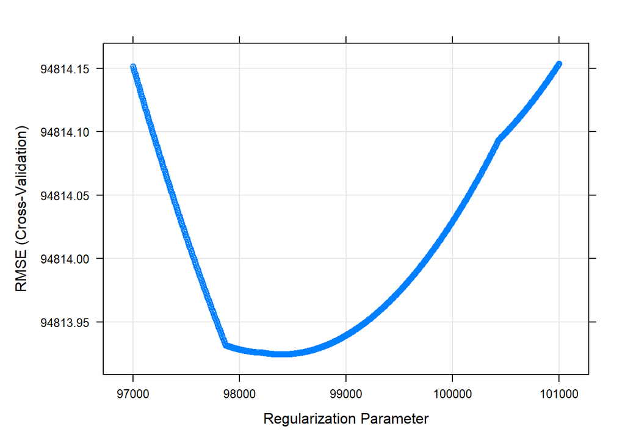

```r
set.seed(101)

ridge2 = train(salary ~ . - sl_no, data = train.data,
            method = "glmnet",
            preProcess = "scale",
            trControl = trainControl("cv", number = 10),
            tuneGrid = expand.grid(alpha = 0,
                                   lambda = seq(97000, 101000, by = 5))
)

plot(ridge2)
```

- 4 points: Syntax is correct and uses a tuneGrid with a tighter interval around 100,000, with a smaller step than what we used before.
- 2 points: Syntax is correct and uses a tuneGrid with a tighter interval around 100,000, but with the same step than what we used before/ Uses a smaller step but same interval.
- 1 point: Attempts something around $\lambda = 100,000$, but overall not correct.
- 0 points: Any other case.

**2.4a) Finally, let’s test out a lasso regression. In this case, use a grid for the tuning parameter between 0 and 30,000 with a step of 500. Show your code here:** *(5 points)*

*Answer:*

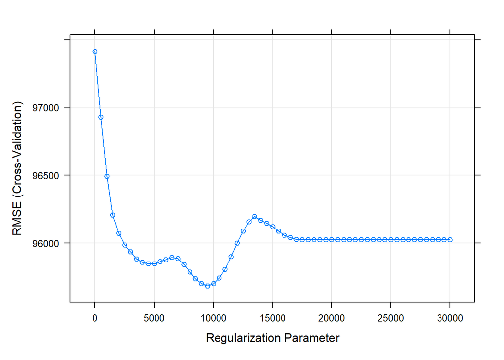

```r
set.seed(101)

lasso = train(salary ~ . - sl_no, data = train.data,
              method = "glmnet",
              preProcess = "scale",
              trControl = trainControl("cv", number = 10),
              tuneGrid = expand.grid(alpha = 1,
                                     lambda = seq(0, 30000, by = 500))
)

plot(lasso)
```

- 5 points: (i) Correct model (outcomes and predictors), (ii) correct method (glmnet), (iii) correct tuneGrid (alpha = 1 and lambda provided), (iv) correct data (train.data)
- 3 point: One of the previous items is not correct.
- 0 points: Any other case.

**2.4b) What is your best tuning parameter in this case?** *(2 points)*

*Answer:*

```r
options(scipen = 999)

lasso$bestTune$lambda
```

```
## [1] 9500
```

**2.4c) Which of the models you have tested so far (in 2.2a, 2.3a, and 2.4a) do you prefer?** *(2 points)*

1. OLS
2. Ridge
3. Lasso

*Answer:*

```r
tab = round(rbind(rmse(lm.fwd, test.data),rmse(ridge, test.data), rmse(lasso, test.data)),2)
colnames(tab) = c("RMSE")
rownames(tab) = c("Stepwise", "Ridge", "Lasso")

tab %>%
  kbl() %>%
  kable_paper("hover", full_width = F)
```

|  | RMSE |
| --- | --- |
| Stepwise | 147591.8 |
| Ridge | 148078.6 |
| Lasso | 147074.3 |

Lasso

**2.4d) Does the Lasso regression you just fitted use more or less predictors than the stepwise model from 2.2a?** *(3 points)*

1. More predictors
2. Same predictors
3. Less predictors

*Answer:*

```r
# Predictors for stepwise
lm.fwd$bestTune$nvmax
```

```
## [1] 10
```

```r
# Predictors for Lasso
coefs = coef(lasso$finalModel, lasso$bestTune$lambda)

coefs@p[2] - 1
```

```
## [1] 3
```

Less predictors

# Task 3 - IBM knows you are leaving

Trying to predict the risk of losing an employee is critical if you want to keep talent within your company and avoid having a high turnover rate. For this task, you will be working with data from a company which contains information about employees and whether they left the company or not.

```r
employees = read.csv("https://raw.githubusercontent.com/maibennett/sta235/main/exampleSite/content/Assignments/Homework/Homework5/data/employees.csv") %>%
  select(-c(EmployeeCount, Over18, StandardHours))
```

*Note: We remove three variables that have no variation in this dataset.*

You can see a codebook of the variables [here](https://raw.githubusercontent.com/maibennett/sta235/main/exampleSite/content/Assignments/Homework/Homework5/data/employees_codebook.txt)

Our goal is to best predict whether an employee will leave their company or not, given their characteristics.

For this task, use a seed of 122 before any code that uses some random selection. You can also use 10-fold cross-validation when needed, and an 70%-30% split for your training (`train.data`) and testing (`test.data`) datasets.

*Note: Be sure to exclude (not drop) variables that are not predictors.*

**3.1) Let’s start preparing our data. Transform the variables `Education`, `EnvironmentSatisfaction`, `JobInvolvement`, `JobSatisfaction`, `PerformanceRating`, `RelationshipSatisfaction`, and `WorkLifeBalance` to categorical (factor) variables and split our data 70-30 for training and testing purposes. Show your code here:** *(4 points)*

*Answer:*

```r
set.seed(122)

employees = employees %>% mutate(across(c(Education, EnvironmentSatisfaction,
                                          JobInvolvement, JobSatisfaction, PerformanceRating,
                                          RelationshipSatisfaction, WorkLifeBalance),
                                        ~ as.factor(.x)))

n = nrow(employees)

train = sample(1:n, 0.7*n)

train.data = employees %>% slice(train)
test.data = employees %>% slice(-train)
```

- 4 points: Correctly transforms the given variables into factors (either like this or one by one) and slices the data 70-30.
- 2 points: One of the previous items is not correct.
- 0 points: Any other case.

**3.2) Let’s examine our data. Create a binary variable that takes the value of 1 if the employee’s job satisfaction is “High” or “Very high” and use that variable in addition to age, gender, marital status, and monthly income. Compare these characteristics between all employees that have quit and those who have not using a balance table. What can you say about these differences? Give an overall explanation and highlight some of the main differences/similarities.** *(8 points)*

*Answer: Looking at the table below, we can see that, on average, employees that quit have lower job satisfaction, tend to be younger, and more likely to be single. They also have, on average, lower income. There doesn’t seem to be a relevant spread between female employees or male employees that quit, though.*

```r
employees_bal = employees %>% mutate(HighJobSatisfaction = ifelse(JobSatisfaction=="3" | JobSatisfaction=="4", 1, 0),
                                      Female = ifelse(Gender == "Female", 1, 0),
                                      Married = ifelse(MaritalStatus=="Married", 1, 0),
                                      Single = ifelse(MaritalStatus=="Single", 1, 0),
                                      Divorced = ifelse(MaritalStatus=="Divorced", 1, 0)) %>%
  select(Attrition, HighJobSatisfaction, age, Female, Married, Single, Divorced, MonthlyIncome)

datasummary_balance(~ Attrition, data = employees_bal, dinm_statistic = "p.value", fmt = 2)
```

|  | 0 Mean | 0 Std. Dev. | 1 Mean | 1 Std. Dev. | Diff. in Means | p |
| --- | --- | --- | --- | --- | --- | --- |
| HighJobSatisfaction | 0.63 | 0.48 | 0.53 | 0.50 | -0.10 | <0.01 |
| age | 37.56 | 8.89 | 33.61 | 9.69 | -3.95 | <0.01 |
| Female | 0.41 | 0.49 | 0.37 | 0.48 | -0.04 | 0.25 |
| Married | 0.48 | 0.50 | 0.35 | 0.48 | -0.12 | <0.01 |
| Single | 0.28 | 0.45 | 0.51 | 0.50 | 0.22 | <0.01 |
| Divorced | 0.24 | 0.43 | 0.14 | 0.35 | -0.10 | <0.01 |
| MonthlyIncome | 6832.74 | 4818.21 | 4787.09 | 3640.21 | -2045.65 | <0.01 |

- 8 points: (i) Balance table includes the right variables (mentioned here), (ii) Categorical variables are changed to binary, (iii) Groups are formed correctly (attrition=0 vs attrition=1), and (iv) interprets differences correctly.
- 6 points: One of the previous items is not correct.
- 4 points: Two of the previous items are not correct.
- 0 points: Any other case.

**3.3a) Build a decision tree using 10-fold cross-validation for this task. Use a grid for the tuning parameter between 0 and 0.15, with length 100. Show your code here:** *(5 points)*

*Answer:*

```r
set.seed(122)

ct = train(
  factor(Attrition) ~ . - EmployeeNumber, data = train.data,
  method = "rpart",
  trControl = trainControl("cv", number = 10),
  tuneGrid = expand.grid(cp = seq(0, 0.15, length = 100))
)
```

- 5 points: (i) Correct outcome (factor(Attrition)), (ii) Correct predictors (excludes EmployeeNumber), (iii) correct method (rpart), (iv) correct tuneGrid, (v) correct data (train.data)
- 3 point: One of the previous items is not correct.
- 0 points: Any other case.

**3.3b) Show the appropriate plot between performance and the tuning parameter:** *(3 points)*

*Answer:*

```r
plot(ct)
```

[figure not shown]

- 3 points: Plots Accuracy vs cp and it matches the answer key.
- 2 points: Plots Accuracy vs cp but it doesn’t match the answer key.
- 1 points: Plots RMSE vs cp
- 0 points: Any other case.

**3.3c) What is the best tuning parameter in this case?** *(Round your answer to 4 decimal places)* *(2 points)*

*Answer:*

```r
ct$bestTune$cp
```

```
## [1] 0.02121212
```

0.0212

**3.3d) Show a plot of your decision tree:** *(2 points)*

*Answer:*

```r
library(rattle)

fancyRpartPlot(ct$finalModel, caption = "Classification tree for predicting attrition")
```

[figure not shown]

- 2 points: Plot matches answer key
- 1 points: Plots a decision tree but doesn’t match the key
- 0 points: Any other case.

**3.3e) Which is the group that is most likely to quit according to your decision tree?** *(3 points)*

*Answer:*

In terms of the group that is most likely to quit, we get that employees that have worked for less than 1.5 years and that are paid overtime are the most likely to quit (94% propensity)*

- 3 points: Identifies the correct group
- 2 points: Identifies the incorrect group according to the key, but is consistent with the previous plot.
- 0 points: Any other case.

**3.4) How does your previous decision tree perform? Show the appropriate performance measure here:** *(Round your answer to 3 decimal places)* *(4 points)*

```r
pred.attrition = ct %>% predict(test.data)

mean(test.data$Attrition==pred.attrition) %>% round(.,3)
```

```
## [1] 0.853
```

**3.5) What is the prediction in terms of attrition for an individual with the following characteristics:** *(4 points)*

- DailyRate: 802
- Education: Bachelor
- Department: Sales
- EnvironmentSatisfaction: Medium
- HourlyRate: 66
- Gender: Female
- Age: 30
- MonthlyIncome: 4919
- MaritalStatus: Married
- Overtime: No
- TotalWorkingYears: 7
- YearsAtCompany: 4

*Answer:*

0

**3.6) Taking into account your previous results, what is one intervention that you would propose in your company to increase retention?** *(4 points)*

*Answer:* It seems that individuals with less work experience that are asked to work overtime (and are paid separately for this) are the ones most likely to quit. Limiting overtime or changing the pay structure for these individuals might be a way to increase retention, in addition to increasing wages.

- 4 points: Makes a suggestion that is consistent with the group found in 3.3e) (suggestions must be reasonable)
- 2 points: Makes a suggestion that doesn’t relate to the group found in 3.3e) (suggestions must be reasonable)
- 0 points: Any other case.